# High School Seniors Analysis

```r
library(tidyverse)
library(DT)
library(pander)
library(readr)
library(mosaic)
library(car)

HSS <- read_csv("../../Data/HighSchoolSeniors.csv")
#If this code does not work:
#Use the top menu from RStudio's window to select "Session, Set Working Directory, To Source File Location", and then play this R-chunk into your console to read the HSS data into R.

## In your Console run View(HSS) to ensure the data has loaded correctly.
```

## Do High School Seniors who come from larger occupancy homes spend more time with family?

### Independent Samples T-test

#### Background

Many parents want close family bonds, even as their children get older. **This analysis examines whether there is a significant difference in time spent with family between high school seniors living in high-occupancy households and those living in low-occupancy households.** The results of this analysis could serve as a factor that parents can consider for family planning.

This analysis defines low occupancy by households with 4 or less members and high occupancy as households with 5 or more members. 5 may seem like a low number, but sources show that the median household occupancy in the United States is 2.5.

#### Hypothesis

$$H_0: \mu_{LowOccupancy} -
\mu_{HighOccupancy} = 0$$
$$H_a:
\mu_{LowOccupancy} - \mu_{HighOccupancy} \neq 0$$
$$\alpha = 0.05$$

#### Cleaning the Data

The data from the data set had to be cleaned. The analysis omitted survey values such as “every”, “idk”, “4-Mar”, “5-Apr” because these survey answers not in line with the survey question or might have been an answer to a different question. Any recorded responses that are higher than 70 hours a week have been filtered out, as it is unlikely that they are spending more than 10 hours a day with family considering 5-7 hours in school and 6-8 hours of sleep.

Values such as “1/2” or “5 hr” have also been cleaned to be in line with formatting and changed to “0.5” or “5”

```r
# Cleaning the data
hoursfriends <- na.omit(HSS) %>%
  select(Home_Occupants, Hanging_Out_With_Friends_Hours, Doing_Things_With_Family_Hours)

#Removing two values which might have been entries for other questions.
hoursfriends <- hoursfriends %>%
  filter(!(Home_Occupants %in% c("4-Mar", "5-Apr")))

hoursfriends <- hoursfriends %>%
  filter(!(Hanging_Out_With_Friends_Hours %in% c("0-10", "doing", "idk")))

hoursfriends <- hoursfriends %>%
  filter(!(Doing_Things_With_Family_Hours %in% c("every", "idk", "24/7", 280, 168)))


df <- hoursfriends %>%
  mutate(
    Friends = case_when(
      Hanging_Out_With_Friends_Hours == "1/2hr" ~ 0.5,
      Hanging_Out_With_Friends_Hours == "24+" ~ 24,
      Hanging_Out_With_Friends_Hours == "5 hr" ~ 5,
      Hanging_Out_With_Friends_Hours == "6h" ~ 6,
      TRUE ~ as.numeric(Hanging_Out_With_Friends_Hours)
    ),
    Home_Occupant = case_when(
      Home_Occupants <= 4 ~ "low Occupancy (1-4)",
      Home_Occupants > 4 ~ "high Occupancy (5+)"
    ),
    Family = case_when(
      Doing_Things_With_Family_Hours == "`20" ~ 20,
      Doing_Things_With_Family_Hours == "0-1" ~ 0.5,
      Doing_Things_With_Family_Hours == "1 hr" ~ 1,
      Doing_Things_With_Family_Hours == "10+" ~ 10,
      Doing_Things_With_Family_Hours == "21hr" ~ 21,
      Doing_Things_With_Family_Hours == "30 mi" ~ 0.5,
      TRUE ~ as.numeric(Doing_Things_With_Family_Hours))

    ) %>%
  filter(Family <= 70) %>%
  select(Friends, Home_Occupant, Family)
```

#### Graphical Analysis

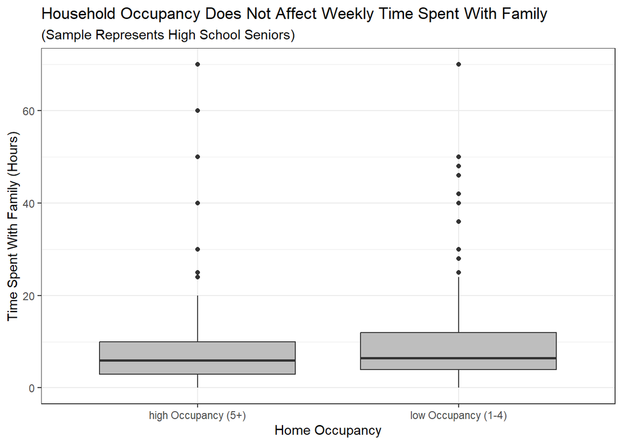

```r
# Boxplot

df %>%
  ggplot(aes(x = Home_Occupant, y = Family))+
  labs(x = "Home Occupancy", y = "Time Spent With Family (Hours)", title = "Household Occupancy Does Not Affect Weekly Time Spent With Family", subtitle = "(Sample Represents High School Seniors)")+
  geom_boxplot(fill = "gray")+ theme_bw()
```

The box plot shown above shows very minimal difference between the time high school seniors who live in homes with high occupancy spend with their family in comparison to high school seniors who live in homes with low occupancy. Those living in homes with low occupancy may seem to spend more time with family slightly, but upon closer inspection, the difference is really minuscule. We can test this by running an independent samples t-test.

#### Statistical Analysis - Checking Test Requirements

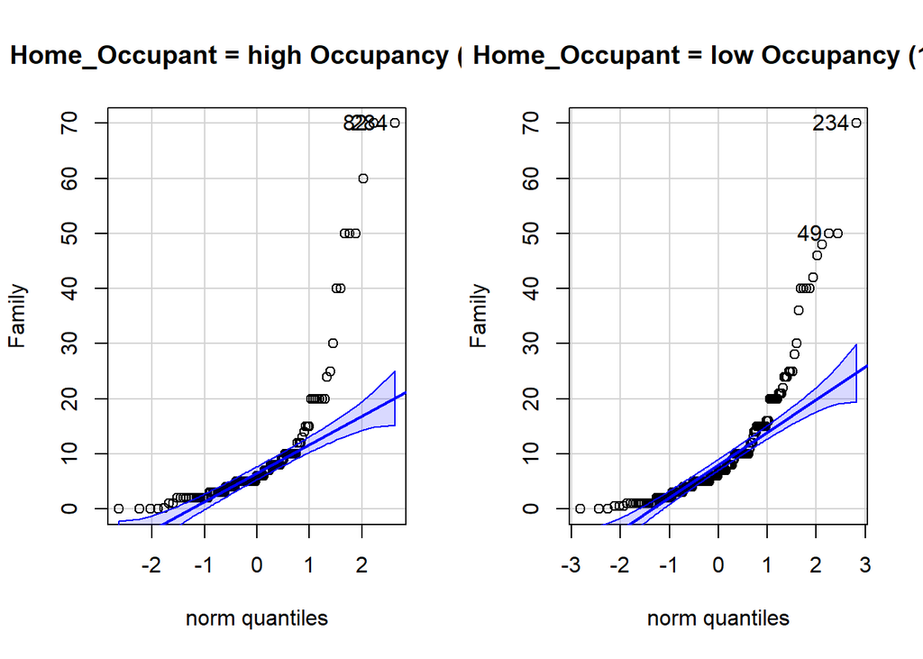

```r
qqPlot(Family ~ Home_Occupant, data = df)
```

#### Sample Count for High School Seniors in High or Low Occupancy Homes

```r
table(df$Home_Occupant) %>%
  pander()
```

| high Occupancy (5+) | low Occupancy (1-4) |
| --- | --- |
| 117 | 208 |

The qqPlot above indicates that the distribution of the difference of the sample means cannot be assumed to be normal because it is showing signs of being skewed. However, because of the central limit theorem, we can assume that because both sample sizes for each group are >30 that performing a t-test will be appropriate.

#### Statistical Analysis - Independent Samples t Test

```r
t.test(Family ~  Home_Occupant, data = df) %>%
  pander()
```

Welch Two Sample t-test: `Family` by `Home_Occupant` (continued below)

| Test statistic | df | P value | Alternative hypothesis |
| --- | --- | --- | --- |
| 0.2275 | 198.8 | 0.8203 | two.sided |

| mean in group high Occupancy (5+) | mean in group low Occupancy (1-4) |
| --- | --- |
| 10.33 | 9.998 |

#### Conclusion

This study aimed to answer whether or not housing occupancy was a factor in the amount of time high school seniors spent with family. The graphical visualizations and statistical tests suggest that it is not. Therefore we can infer that the amount of time high school seniors typically spend with family isn’t affected by household occupancy.

### Wilcoxon Rank Sum Test

#### Background

Many parents want close family bonds, even as their children get older.**This analysis examines whether there is a significant difference in time spent with family between high school seniors living in high-occupancy households and those living in low-occupancy households.** The results of this analysis could serve as a factor that parents can consider for family planning.

This analysis defines low occupancy by households with 4 or less members and high occupancy as households with 5 or more members. 5 may seem like a low number, but sources show that the median household occupancy in the United States is 2.5.

#### Hypothesis

$$Ho: \text{Med}_{LowOccupancy} -
\text{Med}_{HighOccupancy} = 0$$
$$Ha:
\text{Med}_{LowOccupancy} - \text{Med}_{HighOccupancy} \neq 0$$
$$\alpha = 0.05$$

#### Cleaning the Data

The data from the data set had to be cleaned. The analysis omitted survey values such as “every”, “idk”, “4-Mar”, “5-Apr” because these survey answers not in line with the survey question or might have been an answer to a different question. Abnormally large numbers such as spending 280 or 160 hours a week with family have also been omitted as they are unlikely to happen in real life.

Values such as “1/2” or “5 hr” have also been cleaned to be in line with formatting and changed to “0.5” or “5”

```r
# Cleaning the data
hoursfriends <- na.omit(HSS) %>%
  select(Home_Occupants, Hanging_Out_With_Friends_Hours, Doing_Things_With_Family_Hours)

#Removing two values which might have been entries for other questions.
hoursfriends <- hoursfriends %>%
  filter(!(Home_Occupants %in% c("4-Mar", "5-Apr")))

hoursfriends <- hoursfriends %>%
  filter(!(Hanging_Out_With_Friends_Hours %in% c("0-10", "doing", "idk")))

hoursfriends <- hoursfriends %>%
  filter(!(Doing_Things_With_Family_Hours %in% c("every", "idk", "24/7", 280, 168)))


df <- hoursfriends %>%
  mutate(
    Friends = case_when(
      Hanging_Out_With_Friends_Hours == "1/2hr" ~ 0.5,
      Hanging_Out_With_Friends_Hours == "24+" ~ 24,
      Hanging_Out_With_Friends_Hours == "5 hr" ~ 5,
      Hanging_Out_With_Friends_Hours == "6h" ~ 6,
      TRUE ~ as.numeric(Hanging_Out_With_Friends_Hours)
    ),
    Home_Occupant = case_when(
      Home_Occupants <= 4 ~ "low Occupancy (1-4)",
      Home_Occupants > 4 ~ "high Occupancy (5+)"
    ),
    Family = case_when(
      Doing_Things_With_Family_Hours == "`20" ~ 20,
      Doing_Things_With_Family_Hours == "0-1" ~ 0.5,
      Doing_Things_With_Family_Hours == "1 hr" ~ 1,
      Doing_Things_With_Family_Hours == "10+" ~ 10,
      Doing_Things_With_Family_Hours == "21hr" ~ 21,
      Doing_Things_With_Family_Hours == "30 mi" ~ 0.5,
      TRUE ~ as.numeric(Doing_Things_With_Family_Hours))

    ) %>%
  filter(Family <= 70) %>%
  select(Friends, Home_Occupant, Family)
```

#### Graphical Analysis

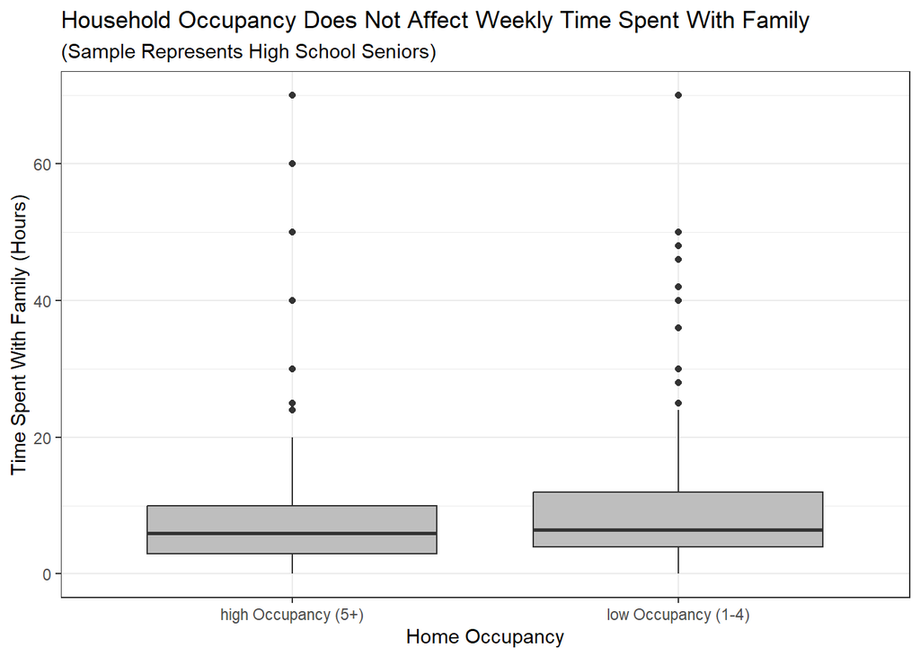

```r
# Boxplot

df %>%
  ggplot(aes(x = Home_Occupant, y = Family))+
  labs(x = "Home Occupancy", y = "Time Spent With Family (Hours)", title = "Household Occupancy Does Not Affect Weekly Time Spent With Family", subtitle = "(Sample Represents High School Seniors)")+
  geom_boxplot(fill = "gray")+ theme_bw()
```

The box plot shown above shows very minimal difference between the time high school seniors who live in homes with high occupancy spend with their family in comparison to high school seniors who live in homes with low occupancy. Those living in homes with low occupancy may seem to spend more time with family slightly, but upon closer inspection, the difference is really minuscule. We can test this by running an Wilcoxon Rank Sum Test.

#### Numerical Summary

```r
favstats(Family ~ Home_Occupant, data = df) %>%
  pander()
```

| Home_Occupant | min | Q1 | median | Q3 | max | mean | sd | n | missing |
| --- | --- | --- | --- | --- | --- | --- | --- | --- | --- |
| high Occupancy (5+) | 0 | 3 | 6 | 10 | 70 | 10.33 | 13.44 | 117 | 0 |
| low Occupancy (1-4) | 0 | 4 | 6.5 | 12 | 70 | 9.998 | 10.66 | 208 | 0 |

#### Wilcoxon Rank Sum Test

```r
wilcox.test(df$Family ~ df$Home_Occupant) %>%
  pander()
```

Wilcoxon rank sum test with continuity correction: `df$Family` by `df$Home_Occupant`

| Test statistic | P value | Alternative hypothesis |
| --- | --- | --- |
| 11497 | 0.4081 | two.sided |

#### Interpretation

Because the P-value > $\alpha = 0.05$ @ 0.4081 we fail to reject the null hypothesis. There isn’t a statistically significant difference in the median values of the amount of time high school seniors who live in high occupancy and low occupancy homes spend with family.